# Wine Quality EDA

### **Box plots for features against quality**

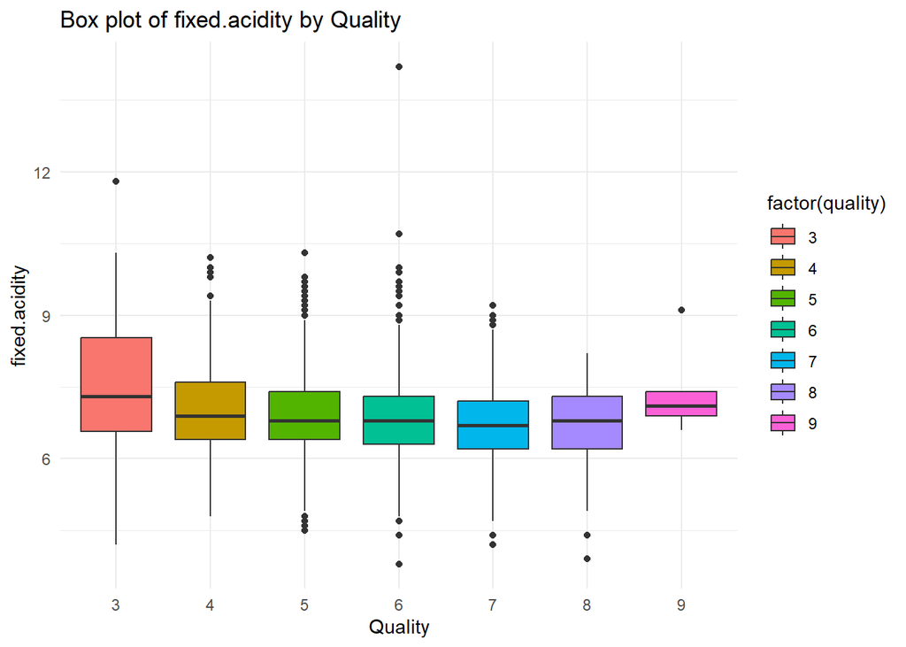

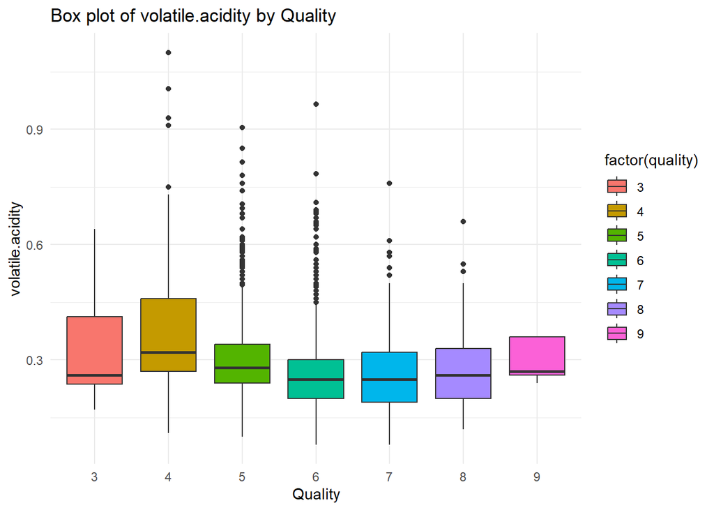

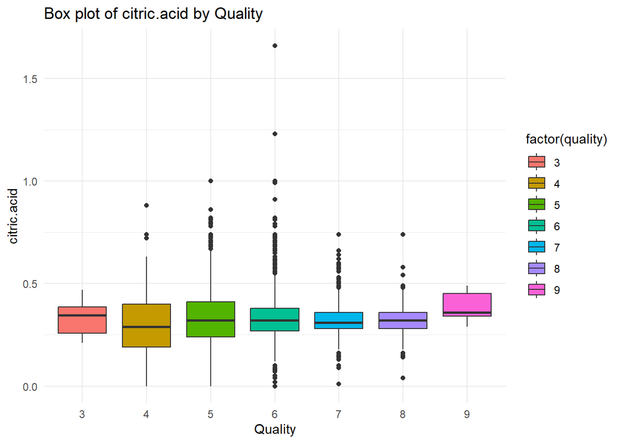

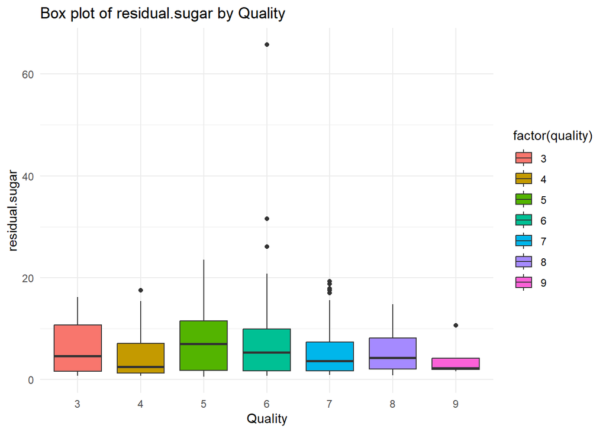

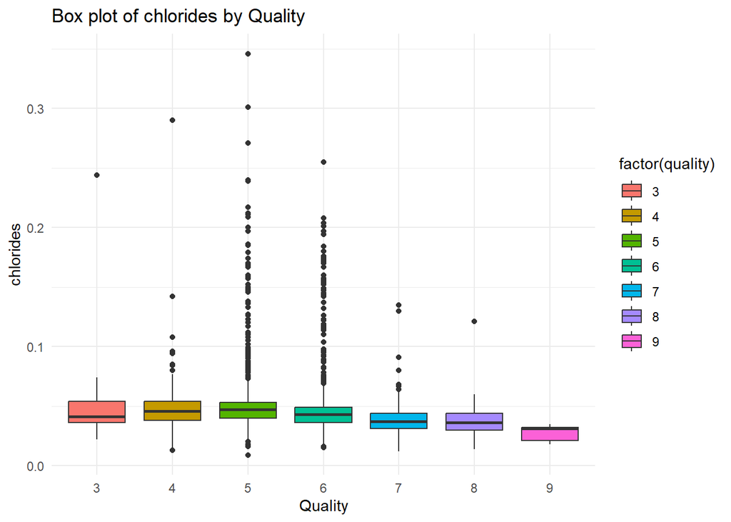

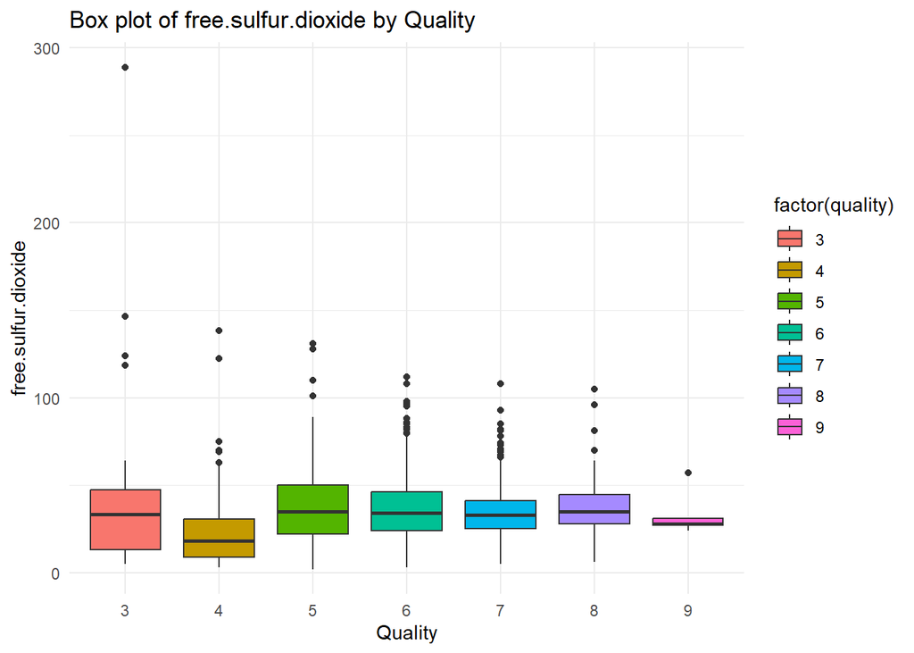

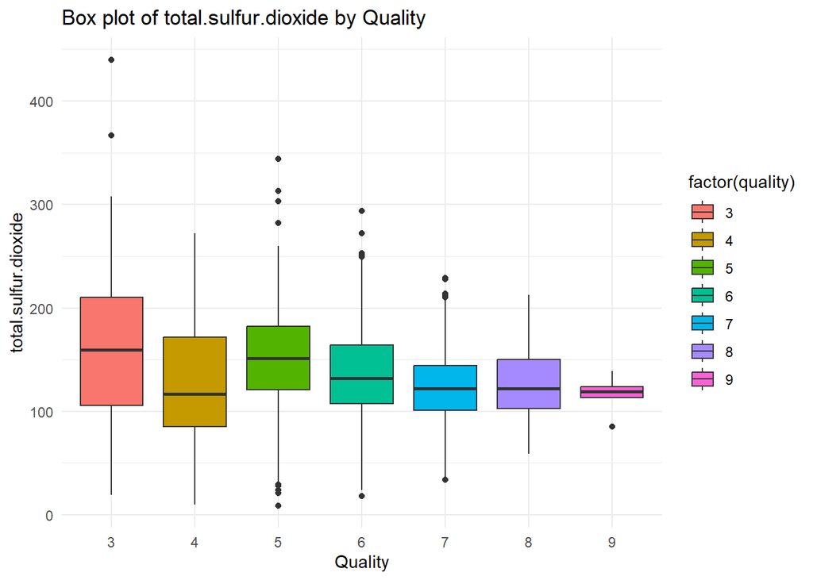

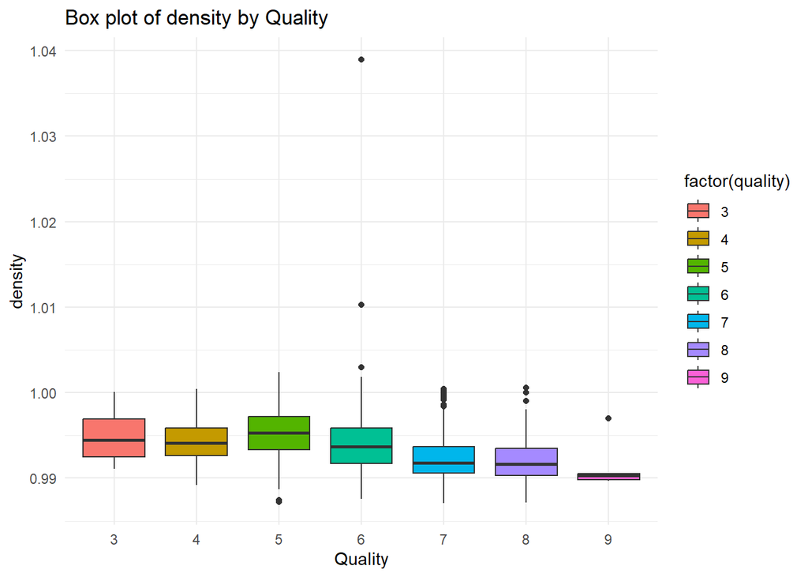

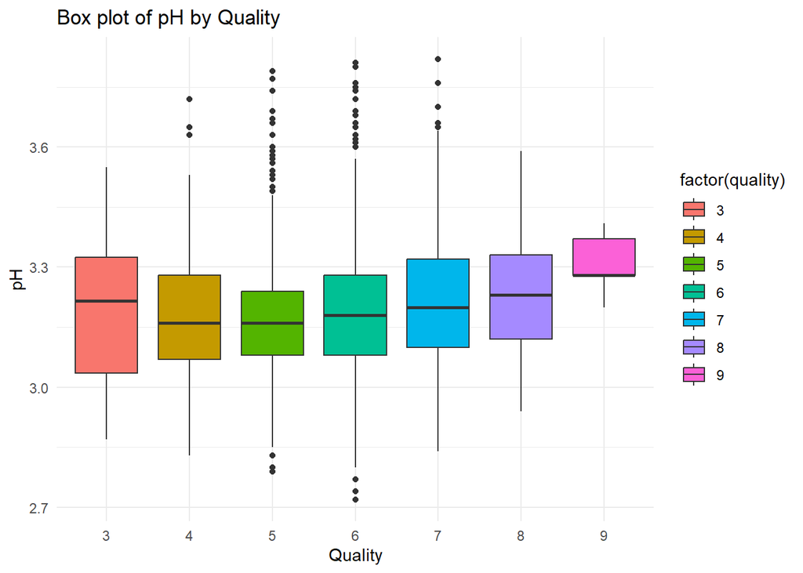

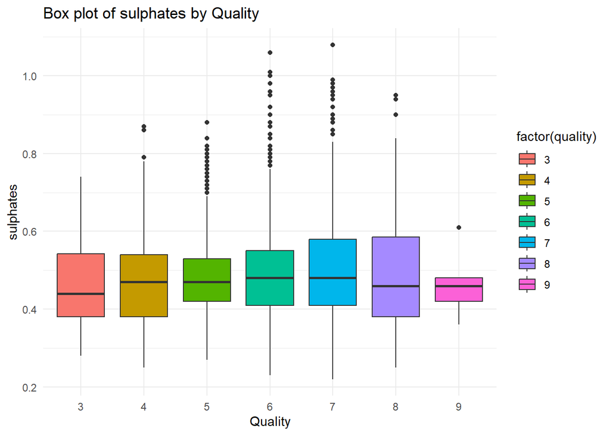

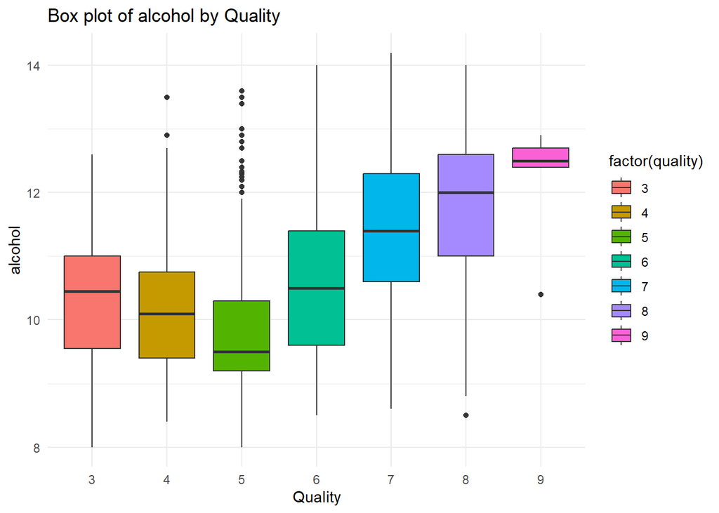

```r
library(ggplot2)
attributes <- names(white_wine[-12])
for(attribute in attributes) {
    p <- ggplot(white_wine, aes(x = factor(quality), y=get(attribute), fill=factor(quality))) +
         geom_boxplot()+
         labs(title=paste("Box plot of", attribute, "by Quality"), x="Quality", y=attribute) +
         theme_minimal()

    print(p)
}
```

**Conclusion**

- Higher `alcohol` levels are associated with higher `quality` wines.
- `Density` decreases with an increase in `quality`, indicating the negative correlation between density and alcohol content.
- Higher `quality` wines have lower amounts of `total sulfur dioxide`.
- Lots of `outliers` are present in `chlorides` and `free sulfur dioxide`.
- `No single factor dominance` in the overall quality.

### **Scatter plots of key features against quality**

```r
#getting the sorted correaltions with quality
key_predictors <- sort(abs(correlation['quality', -ncol(correlation)]), decreasing = TRUE)
key_predictors
```

```
##              alcohol              density            chlorides
##                 0.44                 0.31                 0.21
##     volatile.acidity total.sulfur.dioxide        fixed.acidity
##                 0.19                 0.17                 0.11
##       residual.sugar                   pH            sulphates
##                 0.10                 0.10                 0.05
##          citric.acid  free.sulfur.dioxide
##                 0.01                 0.01
```

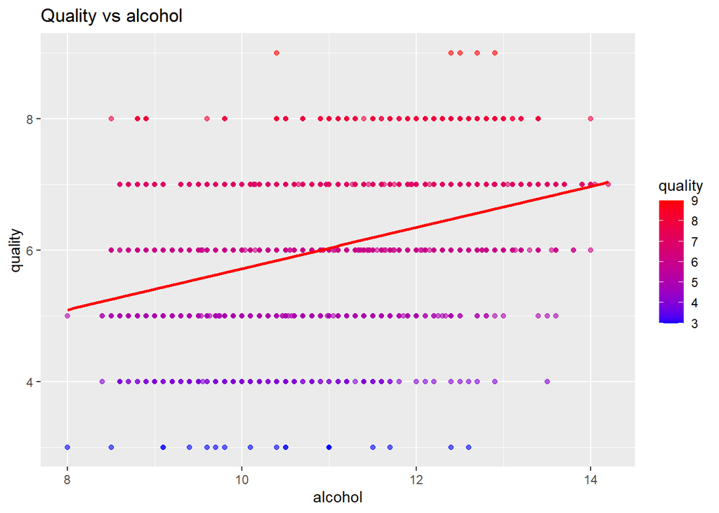

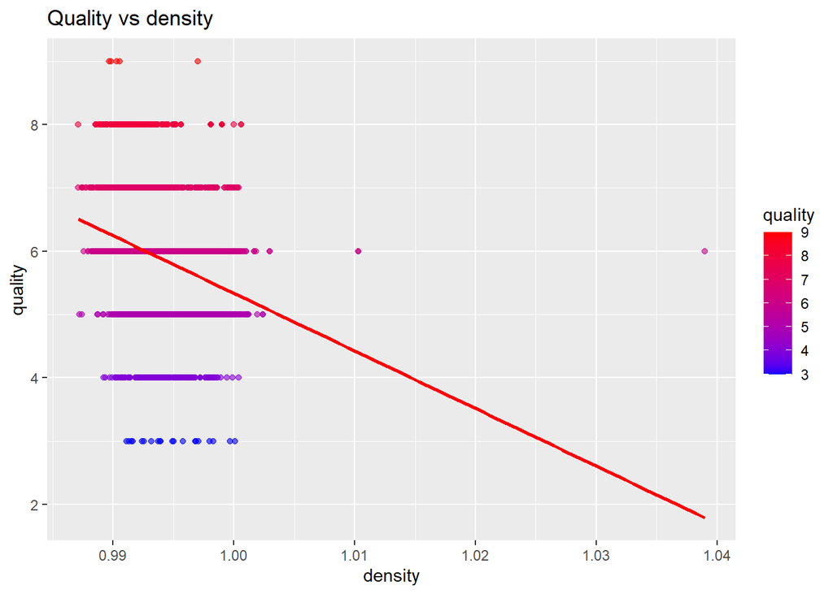

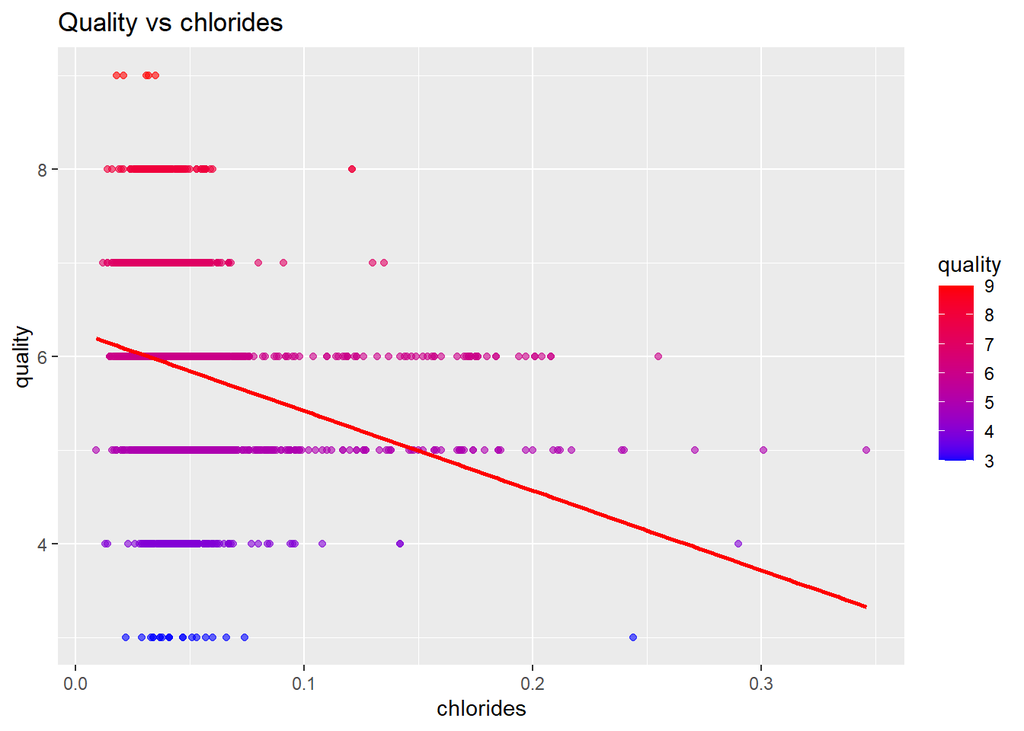

```r
# scatter plots for the top 3 attributes that are correlated with quality target varibale
for (predictor in names(key_predictors)[1:3]) {
  p <- ggplot(white_wine, aes_string(x = predictor, y = "quality", color = 'quality')) +
    geom_point(alpha = 0.6,) +
    geom_smooth(method = "lm", se = FALSE, color = "red") +
    ggtitle(paste("Quality vs", predictor))+
    scale_color_gradient(low = "blue", high = "red")  # Adjust colors as needed

  print(p)
}
```

### **Pair Plots**

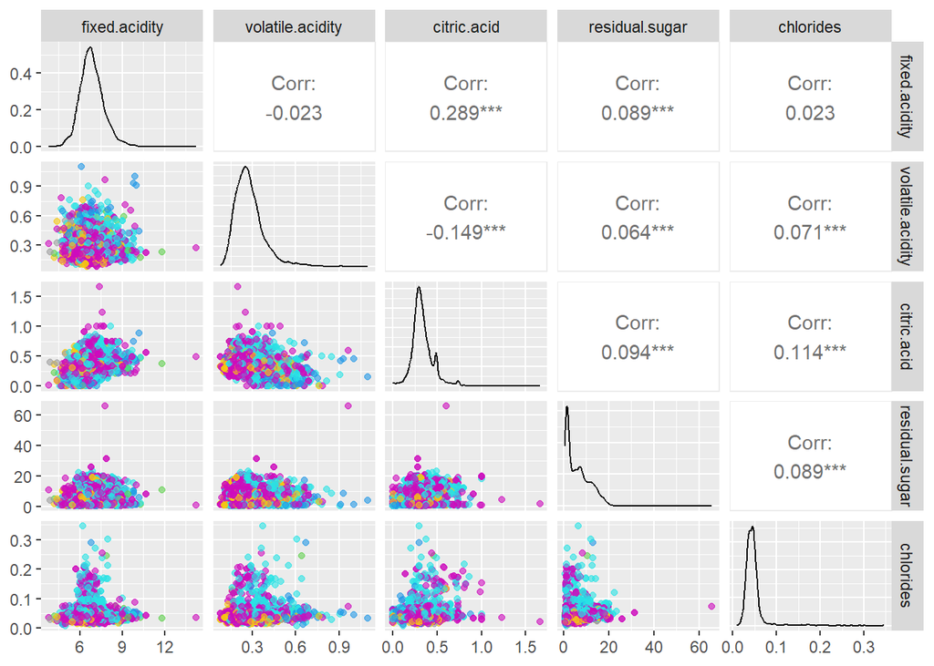

```r
library(GGally)

ggpairs(white_wine[1:5],
        progress = FALSE,
        lower = list(continuous = wrap("points",color = white_wine$quality, alpha = 0.6)))
```

### **Violin Plots**

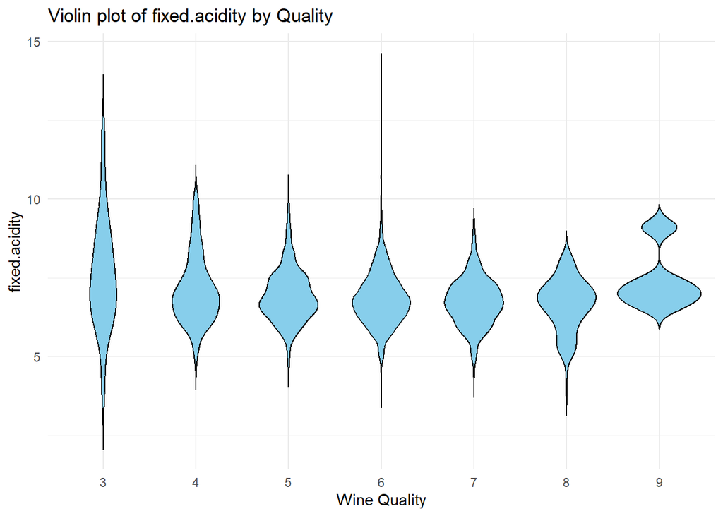

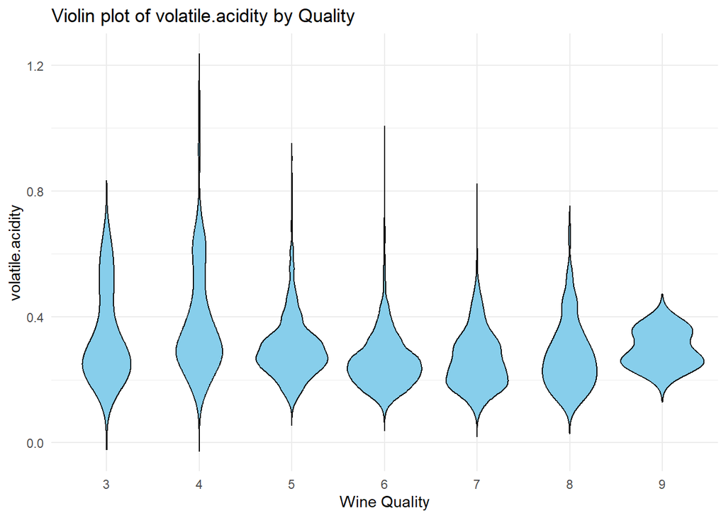

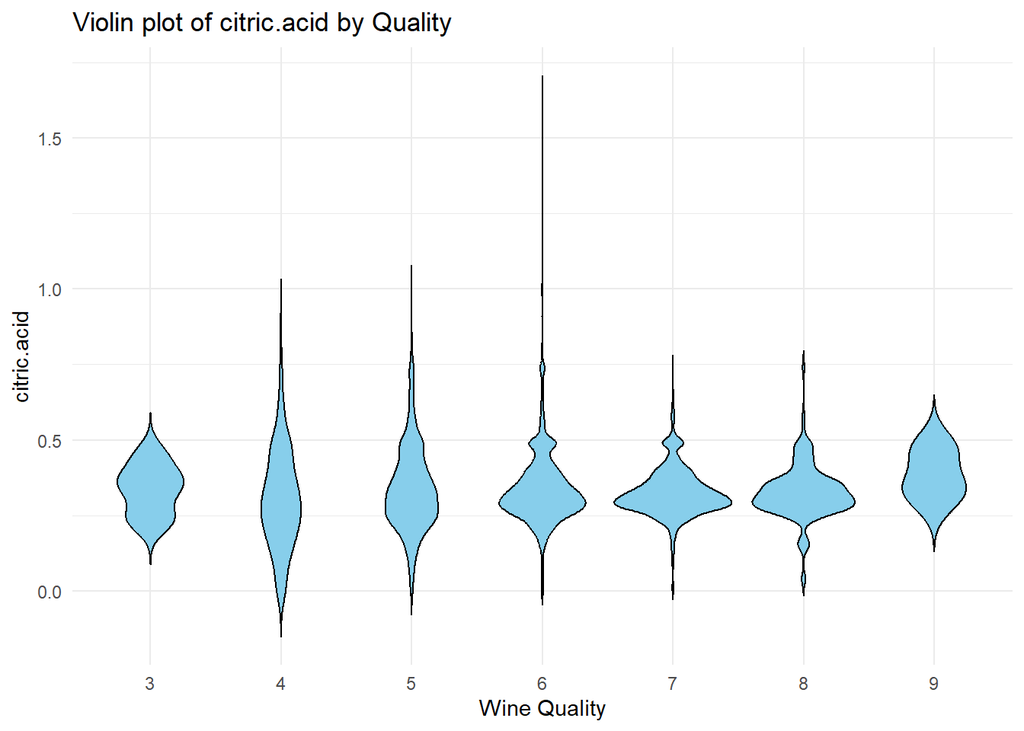

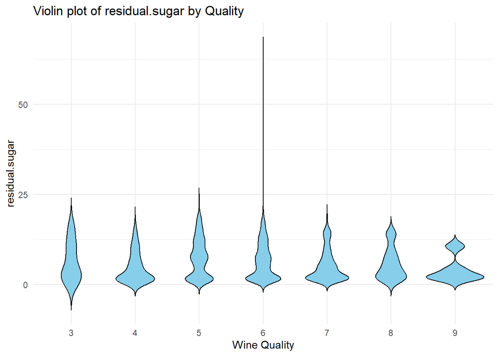

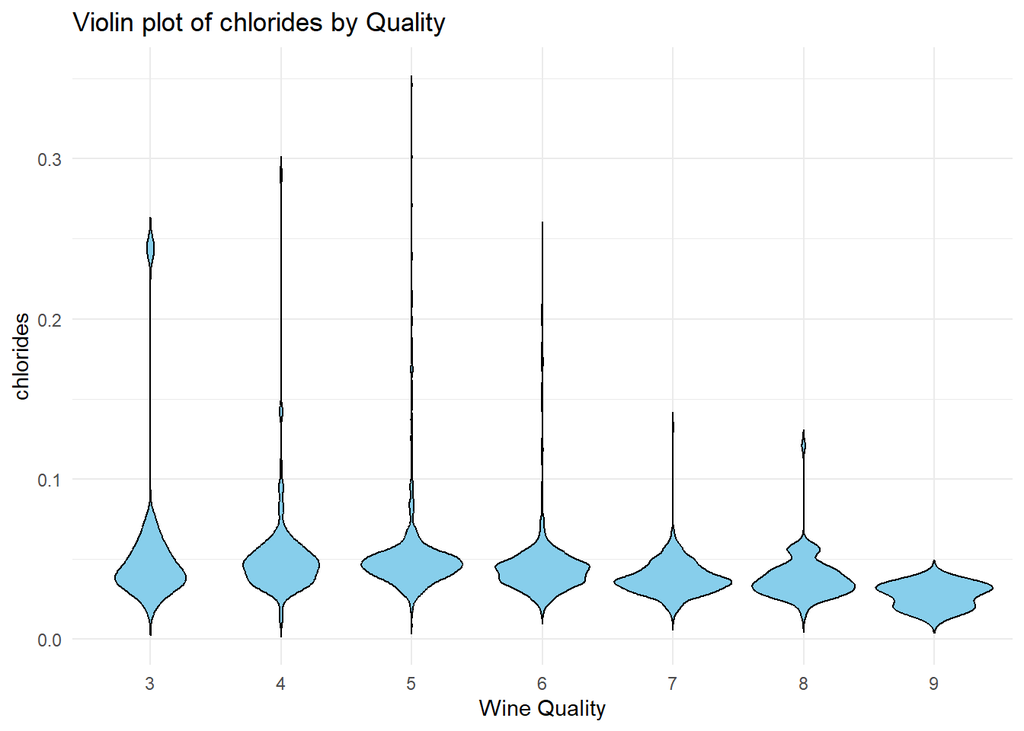

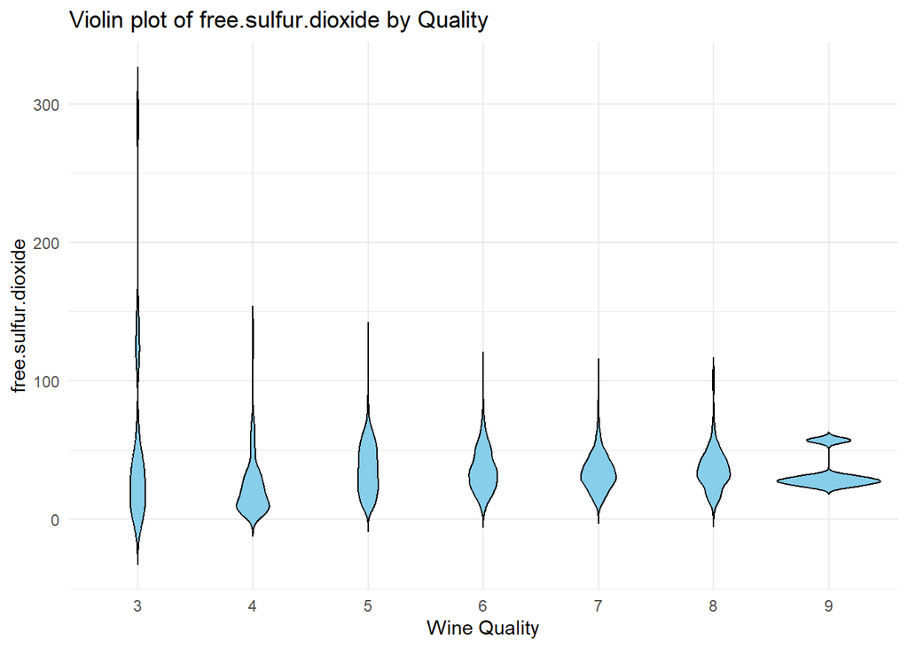

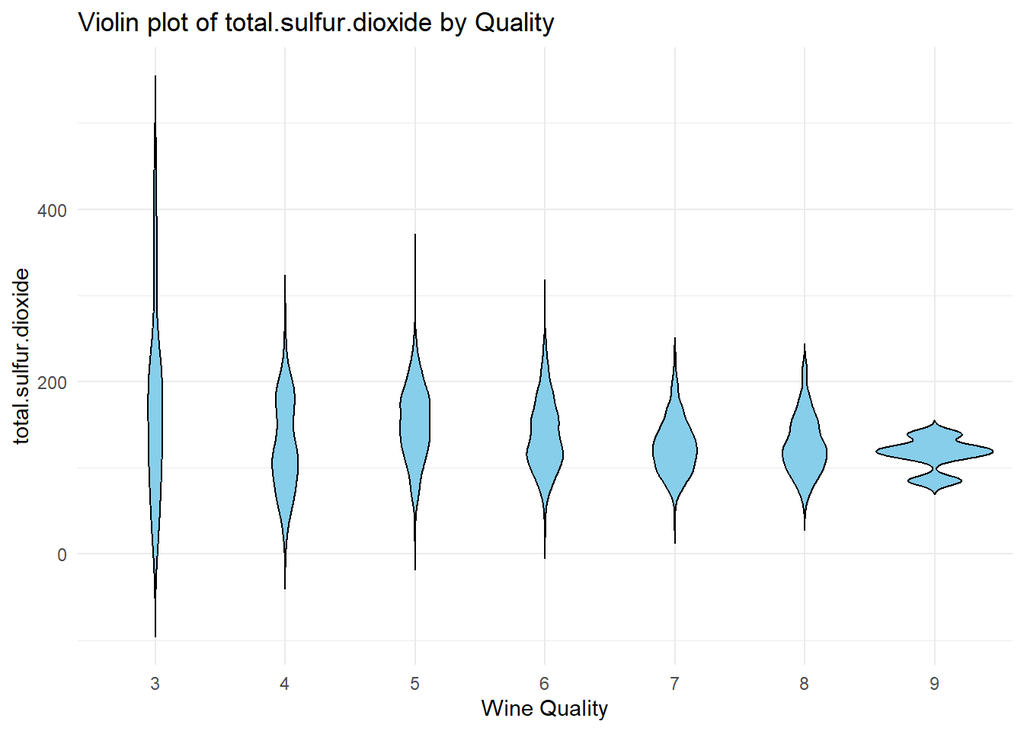

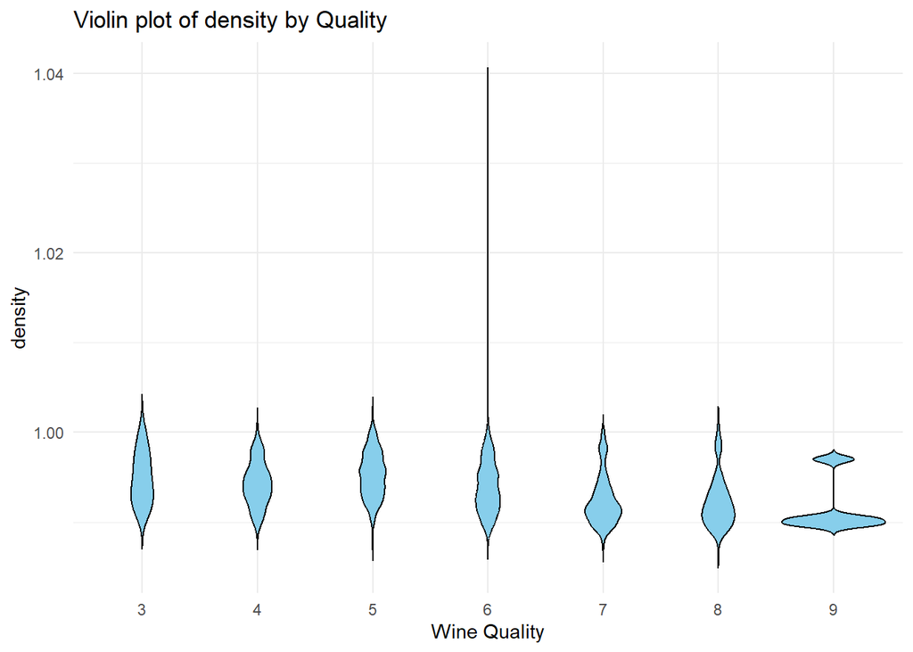

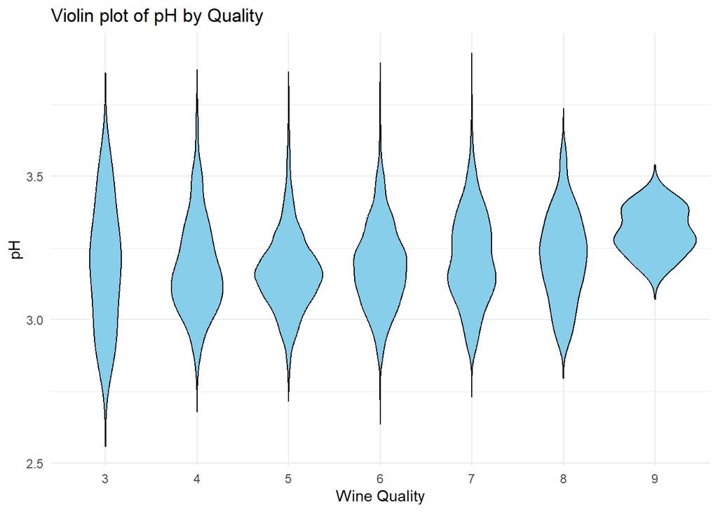

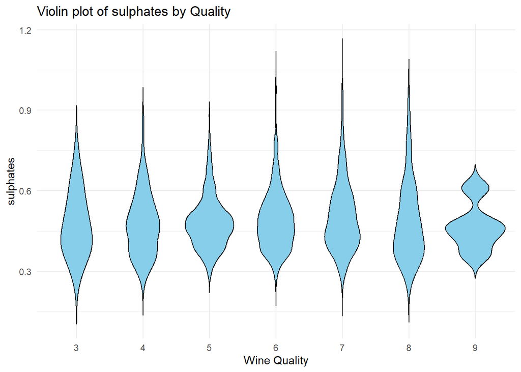

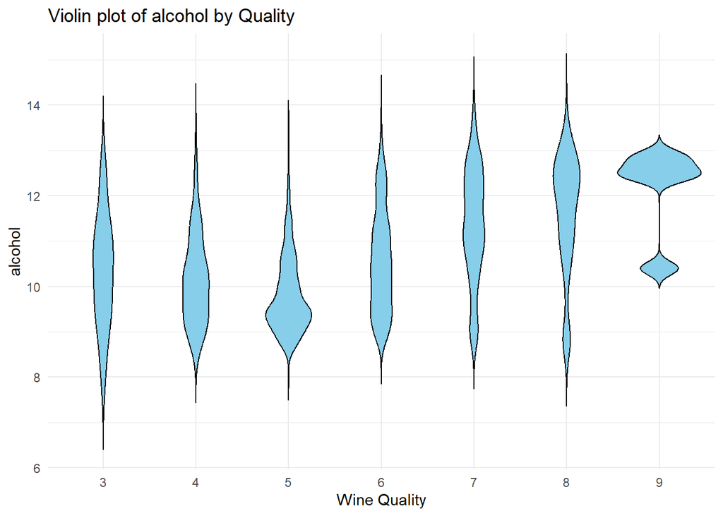

```r
for(attribute in attributes) {
    p <- ggplot(white_wine, aes(x = factor(quality), y = get(attribute))) +
            geom_violin(trim = FALSE, fill = 'skyblue', color = 'black') +
            labs(title=paste("Violin plot of", attribute, "by Quality"), x="Wine Quality", y=attribute) +
            theme_minimal()

    print(p)
}
```

**Conclusion**

- **Presence of outliers in some attributes within specific qualities**

### **PCA**

```r
library(GGally)
white_wine.pca <- princomp(white_wine[, -which(names(white_wine) == "quality")], cor = TRUE)
summary(white_wine.pca)
```

```
## Importance of components:
##                           Comp.1    Comp.2    Comp.3     Comp.4     Comp.5
## Standard deviation     1.7950638 1.2550856 1.1052924 1.00921869 0.98657720
## Proportion of Variance 0.2929322 0.1432036 0.1110610 0.09259294 0.08848496
## Cumulative Proportion  0.2929322 0.4361358 0.5471968 0.63978977 0.72827474
##                            Comp.6     Comp.7     Comp.8     Comp.9    Comp.10
## Standard deviation     0.96888674 0.85240719 0.77418246 0.64353995 0.53804009
## Proportion of Variance 0.08534014 0.06605437 0.05448713 0.03764942 0.02631701
## Cumulative Proportion  0.81361487 0.87966924 0.93415637 0.97180580 0.99812281
##                           Comp.11
## Standard deviation     0.14369790
## Proportion of Variance 0.00187719
## Cumulative Proportion  1.00000000
```

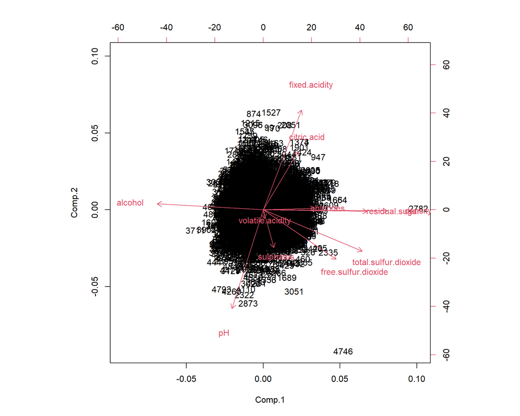

```r
biplot(white_wine.pca)
```

**CONCLUSION**

1. **Data Spread**:-
- data is `concentrated` in the `center`, indicating many wines have `similar` scores on the first `2` compononets.
2. **Arrow Sizes and Directions**
- The attributes which are best represented in the plot is `alcohol` and `density` because they have the `biggest arrows`
- `alcohol` and `density` have high negative `correlation` because the arrows are `opposite` directions
- **It is not possible to direclty evaluate the quality with this representation as we don’t see any separations at all or clusters**